# Conditionsk

# Grid approximation

2.41 - Page 40 (1) Define the grid. This means you decide how many points to use in estimating the posterior, and then you make a list of the parameter values on the grid. (2) Compute the value of the prior at each parameter value on the grid. (3) Compute the likelihood at each parameter value. (4) Compute the unstandardized posterior at each parameter value, by multiplying the prior by the likelihood. (5) Finally, standardize the posterior, by dividing each value by the sum of all values.

```r
posterior
```

```
 [1] 0.000000e+00 7.989837e-07 4.307717e-05 4.090797e-04 1.893887e-03 5.873873e-03 1.404294e-02 2.785174e-02
 [9] 4.780115e-02 7.280739e-02 9.987296e-02 1.242643e-01 1.403143e-01 1.428349e-01 1.289433e-01 9.987296e-02
[17] 6.205890e-02 2.645477e-02 4.659673e-03 0.000000e+00
```

[figure not shown]

```r
plot( p_grid , posterior , type="b" ,
xlab="probability of water" , ylab="posterior probability" )
mtext( "20 points" )
```

## Quadratic approximation

1. Find the posterior mode. This is usually accomplished by some optimization algorithm, a procedure that virtually “climbs” the posterior distribution, as if it were a mountain. The golem doesn’t know where the peak is, but it does know the slope under its feet. There are many well-developed optimization procedures, most of them more clever than simple hill climbing. But all of them try to find peaks.
2. Once you find the peak of the posterior, you must estimate the curvature near the peak. This curvature is sufficient to compute a quadratic approximation of the entire posterior distribution. In some cases, these calculations can be done analytically, but usually your computer uses some numerical technique instead.

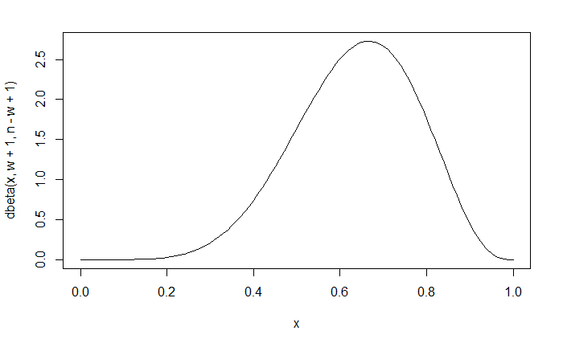